# Explore Relationships and Ancestors

Meera Y. Patel, M.D.

2021-01-16

```r
library(chariot)
library(tidyverse)
library(RColorBrewer)
```

There are 4 different types of relationships represented in the Concept Relationship table depending on whether they are hierarchical and if they define ancestry:

1. Is Hierarchical & Does Not Define Ancestry
2. Is Not Hierarchical & Defines Ancestry
3. Is Hierarchical & Defines Ancestry
4. Is Not Hierarchical & Does Not Define Ancestry

These relationship types can be queried directly in the Relationship table.

```sql
SELECT DISTINCT
  is_hierarchical,
  defines_ancestry
FROM omop_vocabulary.relationship
```

```r
relationship_types <-
  queryAthena(sql_statement =
                "
                SELECT DISTINCT
                  is_hierarchical,
                  defines_ancestry
                FROM omop_vocabulary.relationship
                ")
```

The relationship types are presented as boolean with the following definitions from the [OMOP CDM v5.3.1 wiki](https://ohdsi.github.io/CommonDataModel/cdm531.html#RELATIONSHIP):  
**is_hierarchical**: Defines whether a relationship defines concepts into classes or hierarchies. Values are 1 for hierarchical relationship or 0 if not.  
**defines_ancestry**: Defines whether a hierarchical relationship contributes to the concept_ancestor table. These are subsets of the hierarchical relationships. Valid values are 1 or 0.

```r
relationship_types
```

| is_hierarchical | defines_ancestry |
| --- | --- |
| 1 | 0 |
| 0 | 1 |
| 1 | 1 |
| 0 | 0 |

Though a relationship that defines ancestry is by definition required to also be deemed hierarchical, non-hierarchical relationships that define ancestry appear to exist in the Relationship table.

```sql
SELECT DISTINCT
  c.vocabulary_id AS vocabulary_id_1,
  c.concept_class_id AS concept_class_id_1,
  c2.vocabulary_id AS vocabulary_id_2,
  c2.concept_class_id AS concept_class_id_2,
  cr.relationship_id,
  cr.invalid_reason
FROM omop_vocabulary.relationship r
INNER JOIN omop_vocabulary.concept_relationship cr
ON cr.relationship_id = r.relationship_id
INNER JOIN omop_vocabulary.concept c
ON cr.concept_id_1 = c.concept_id
INNER JOIN omop_vocabulary.concept c2
ON cr.concept_id_2 = c2.concept_id
WHERE
  r.is_hierarchical = 0
    AND r.defines_ancestry = 1
    AND c.invalid_reason IS NULL
    AND c2.invalid_reason IS NULL
```

```r
outliers <-
  queryAthena(sql_statement =
              "
              SELECT DISTINCT
                c.vocabulary_id AS vocabulary_id_1,
                c.concept_class_id AS concept_class_id_1,
                c2.vocabulary_id AS vocabulary_id_2,
                c2.concept_class_id AS concept_class_id_2,
                cr.relationship_id,
                cr.invalid_reason
              FROM omop_vocabulary.relationship r
              INNER JOIN omop_vocabulary.concept_relationship cr
              ON cr.relationship_id = r.relationship_id
              INNER JOIN omop_vocabulary.concept c
              ON cr.concept_id_1 = c.concept_id
              INNER JOIN omop_vocabulary.concept c2
              ON cr.concept_id_2 = c2.concept_id
              WHERE
                r.is_hierarchical = '0'
                  AND r.defines_ancestry = '1'
                  AND c.invalid_reason IS NULL
                  AND c2.invalid_reason IS NULL
              ")  %>%
    mutate(`Vocabulary to Vocabulary` = paste0(vocabulary_id_1, " to ", vocabulary_id_2))
```

The relationships indicate that these types of relationships only exist in the Drug Domain.

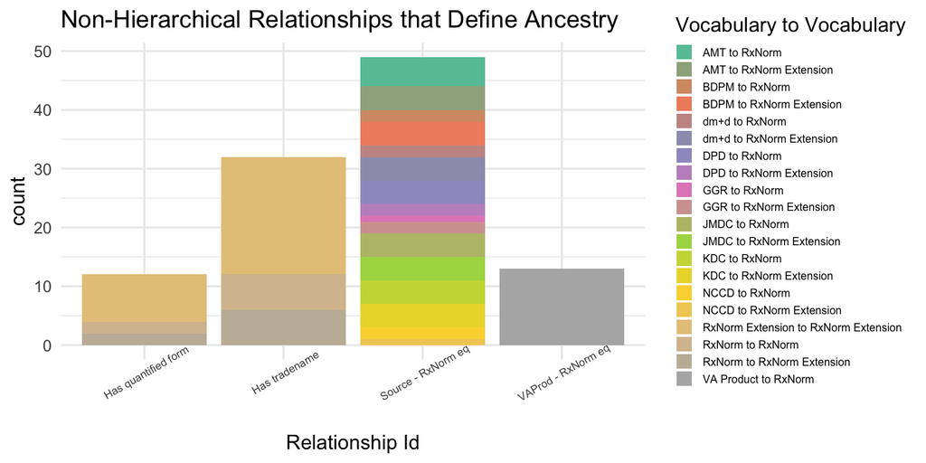

## 0.1 Full Review

For each of the 4 relationship types, any association with select controlled vocabularies SNOMED, LOINC, RxNorm, RxNorm Extension, HemOnc and ATC is derived. Relationships analyzed are filtered for those within each vocabulary system.

### 0.1.1 Methods

Relationships for each relationship type and target vocabulary is queried.

```sql
SELECT
  c.vocabulary_id,
  c.concept_class_id AS concept_class_id_1,
  c2.concept_class_id AS concept_class_id_2,
  r.relationship_id,
  r.is_hierarchical,
  r.defines_ancestry,
  ca.min_levels_of_separation,
  ca.max_levels_of_separation
FROM patelm9.@staging_table t
INNER JOIN omop_vocabulary.relationship r
ON t.is_hierarchical = r.is_hierarchical
    AND t.defines_ancestry = r.defines_ancestry
INNER JOIN omop_vocabulary.concept_relationship cr
ON cr.relationship_id = r.relationship_id
INNER JOIN omop_vocabulary.concept c
ON cr.concept_id_1 = c.concept_id
INNER JOIN omop_vocabulary.concept c2
ON cr.concept_id_2 = c2.concept_id
INNER JOIN omop_vocabulary.concept_ancestor ca
ON ca.ancestor_concept_id = cr.concept_id_1
     AND ca.descendant_concept_id = cr.concept_id_2
WHERE
  c.invalid_reason IS NULL
    AND c2.invalid_reason IS NULL
    AND c.vocabulary_id IN ('@target_vocabulary')
    AND c2.vocabulary_id IN ('@target_vocabulary')
    AND cr.invalid_reason IS NULL
```

```r
# Target vocabularies
target_vocabularies <- c("SNOMED", "LOINC",
                         "RxNorm", "RxNorm Extension",
                         "HemOnc", "ATC")

# Looping over each relationship type
output <- list()
for (i in 1:nrow(relationship_types)) {
  relationship_type <-
    relationship_types %>%
    filter(row_number() == i)

  conn <- connectAthena()
  staging_table <- pg13::write_staging_table(conn = conn,
                                             schema = "patelm9",
                                             data = relationship_type,
                                             drop_existing = TRUE,
                                             drop_on_exit = FALSE)

  output[[i]] <- list()
  # Loop over each target vocabulary by relationship type
  for (j in seq_along(target_vocabularies)) {

    target_vocabulary <- target_vocabularies[j]

    sql_statement <-
      SqlRender::render(
        "
        SELECT
          c.vocabulary_id,
          c.concept_class_id AS concept_class_id_1,
          c2.concept_class_id AS concept_class_id_2,
          r.relationship_id,
          r.is_hierarchical,
          r.defines_ancestry,
          ca.min_levels_of_separation,
          ca.max_levels_of_separation
        FROM patelm9.@staging_table t
        INNER JOIN omop_vocabulary.relationship r
        ON t.is_hierarchical = r.is_hierarchical
            AND t.defines_ancestry = r.defines_ancestry
        INNER JOIN omop_vocabulary.concept_relationship cr
        ON cr.relationship_id = r.relationship_id
        INNER JOIN omop_vocabulary.concept c
        ON cr.concept_id_1 = c.concept_id
        INNER JOIN omop_vocabulary.concept c2
        ON cr.concept_id_2 = c2.concept_id
        INNER JOIN omop_vocabulary.concept_ancestor ca
        ON ca.ancestor_concept_id = cr.concept_id_1
             AND ca.descendant_concept_id = cr.concept_id_2
        WHERE
          c.invalid_reason IS NULL
            AND c2.invalid_reason IS NULL
            AND c.vocabulary_id IN ('@target_vocabulary')
            AND c2.vocabulary_id IN ('@target_vocabulary')
            AND cr.invalid_reason IS NULL
        ",
        staging_table = staging_table,
        target_vocabulary = target_vocabulary
      )

    output[[i]][[j]] <-
      queryAthena(sql_statement = sql_statement)
    names(output[[i]])[j] <- target_vocabulary

  }

  pg13::drop_all_staging_tables(conn = conn,
                                schema = "patelm9")
  dcAthena(conn = conn)
}

# Add names to output
relationship_type_labels <-
  c("Is Hierarchical & Does Not Define Ancestry",
    "Is Not Hierarchical & Defines Ancestry",
    "Is Hierarchical & Defines Ancestry",
    "Is Not Hierarchical & Does Not Define Ancestry")
names(output) <- relationship_type_labels

R.cache::saveCache(object = output,
                   dirs = "chariot/vignettes/explore-relationships-and-ancestors/",
                   key = list("output")
                   )
```

The relationships are counted by relationship type.

```r
# Bind outputs by relationship type
output2_a <-
  output %>%
  map(bind_rows) %>%
  # Rename target fields for aesthetics in plots
  map(function(x) x %>% rename(Vocabulary = vocabulary_id)) %>%
  # Add relationship_id count
  map(group_by,relationship_id) %>%
  map(mutate, count = length(relationship_id)) %>%
  map(ungroup) %>%
  # Convert controlled vocabularies to factors
  map(mutate_at, vars(Vocabulary), ~ factor(.,
                                       levels = c("SNOMED",
                                                  "LOINC",
                                                  "RxNorm",
                                                  "RxNorm Extension",
                                                  "ATC",
                                                  "HemOnc")))
```

The distribution of `max_levels_of_separation` and `min_levels_of_separation` is also assessed by relationship type.

```r
output2_b <-
  output %>%
  map(bind_rows) %>%
  map(function(x) x %>%
        pivot_longer(cols = c(min_levels_of_separation,
                              max_levels_of_separation),
                     names_to = "Type of Separation",
                     values_to = "level_of_separation")) %>%
  map(function(x) x %>%
        mutate_at(vars(`Type of Separation`),
                function(y) case_when(y %in% c("max_levels_of_separation") ~ "Max",
                                      TRUE ~ "Min")))
```

### 0.1.2 Results

#### 0.1.2.1 Hierarchical & Does Not Define Ancestry

There are zero relationships that are hierarchical, but do not define ancestry in the select controlled vocabularies.

#### 0.1.2.2 Not Hierachical & Define Ancestry

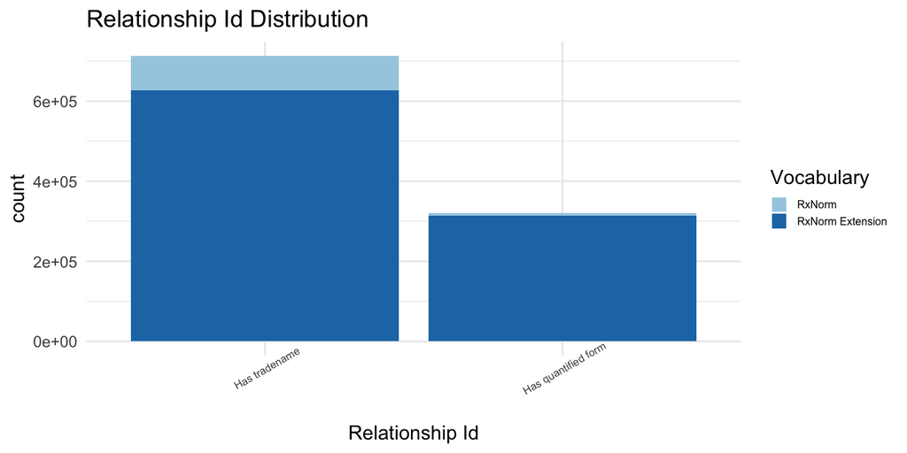

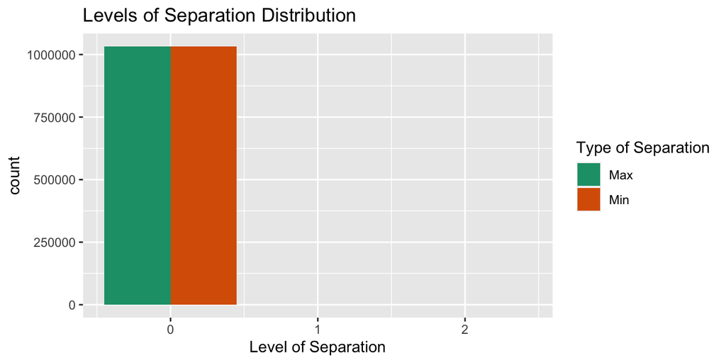

[figure not shown]

[figure not shown]

#### 0.1.2.4 Not Hierarchical and Do Not Define Ancestry

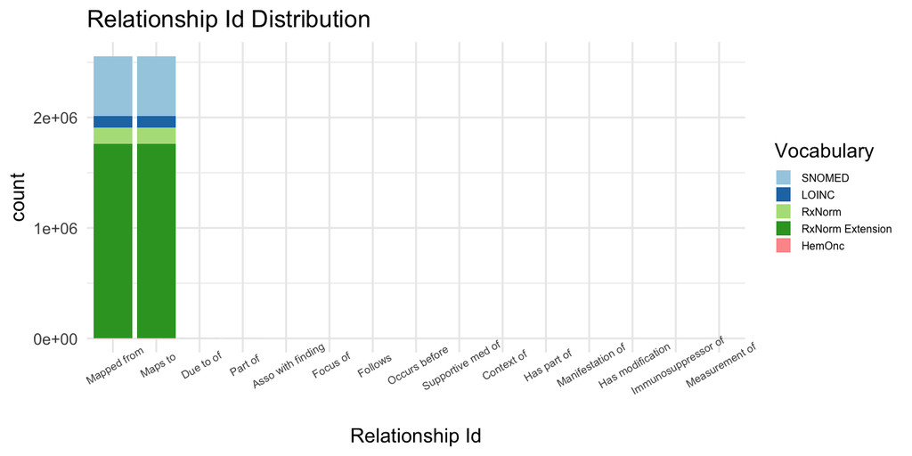

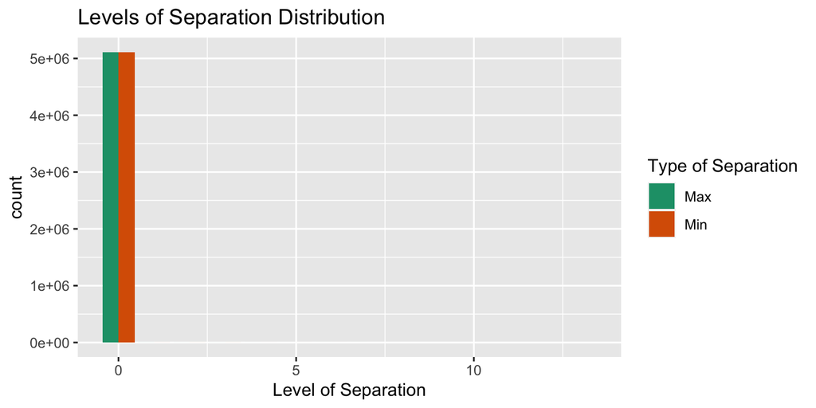